# Project 2: RNA-seq Analysis

## FGSEA Analysis

```r
if (!require("fgsea")) {
  BiocManager::install("fgsea")
}
library(fgsea)
library(dplyr)
library(tibble)
```

```r
deseq2_res_ordered <- merged_res %>%
  drop_na(log2FoldChange, gene_name) %>%
  distinct(gene_name, .keep_all = TRUE) %>%
  arrange(desc(log2FoldChange))

rnk_list <- setNames(deseq2_res_ordered$log2FoldChange, deseq2_res_ordered$gene_name)

head(rnk_list, 10)
```

```
##          ZNF558 ENSG00000290461         SLC2A14        PCDHGA10 ENSG00000290588
##       12.271037        7.237184        4.687023        4.482379        4.450196
## ENSG00000290901 ENSG00000282914 ENSG00000180458 ENSG00000289575             REN
##        3.928760        3.760454        3.747871        3.699572        3.150114
```

```r
library(fgsea)
library(dplyr)
library(tibble)

pathways <- gmtPathways("results/c2.cp.v2025.1.Hs.symbols.gmt")


fgseaRes <- fgsea(pathways = pathways,
stats = rnk_list,
minSize = 15,
maxSize = 500)


fgseaRes <- fgseaRes[order(padj), ]
head(fgseaRes)
```

```
##                                                                  pathway
##                                                                   <char>
## 1:                                              REACTOME_NEURONAL_SYSTEM
## 2:                                            PID_P53_DOWNSTREAM_PATHWAY
## 3:                                       WP_ADHD_AND_AUTISM_ASD_PATHWAYS
## 4:                      WP_CELL_LINEAGE_MAP_FOR_NEURONAL_DIFFERENTIATION
## 5:                                                 PID_INTEGRIN1_PATHWAY
## 6: REACTOME_ASSEMBLY_OF_COLLAGEN_FIBRILS_AND_OTHER_MULTIMERIC_STRUCTURES
##            pval         padj   log2err         ES       NES  size  leadingEdge
##           <num>        <num>     <num>      <num>     <num> <int>       <list>
## 1: 7.314501e-11 1.740851e-07 0.8390889 -0.5218745 -1.951470   353 SLITRK2,....
## 2: 2.811444e-07 3.345618e-04 0.6749629  0.5953292  2.082911   135 TP63, SP....
## 3: 6.740017e-07 5.347080e-04 0.6594444 -0.4726943 -1.759476   319 PNPO, CN....
## 4: 3.164868e-06 1.883096e-03 0.6272567 -0.5985573 -1.982258   105 SLC6A2, ....
## 5: 1.097232e-05 3.730588e-03 0.5933255  0.6501833  2.032373    65 LAMA4, C....
## 6: 9.231557e-06 3.730588e-03 0.5933255  0.6865184  2.092815    52 COL6A6, ....
```

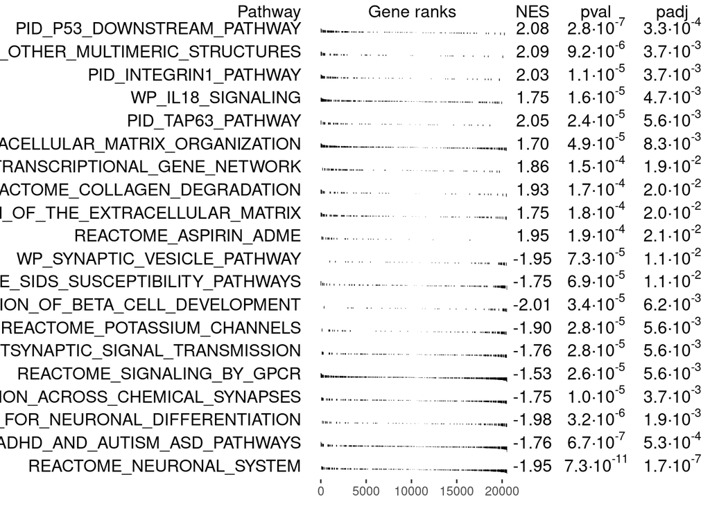

```r
topPathwaysUp <- fgseaRes[ES > 0][head(order(pval), n = 10), pathway]
topPathwaysDown <- fgseaRes[ES < 0][head(order(pval), n = 10), pathway]
topPathways <- c(topPathwaysUp, rev(topPathwaysDown))

plotGseaTable(pathways[topPathways], rnk_list, fgseaRes, gseaParam = 0.5)
```

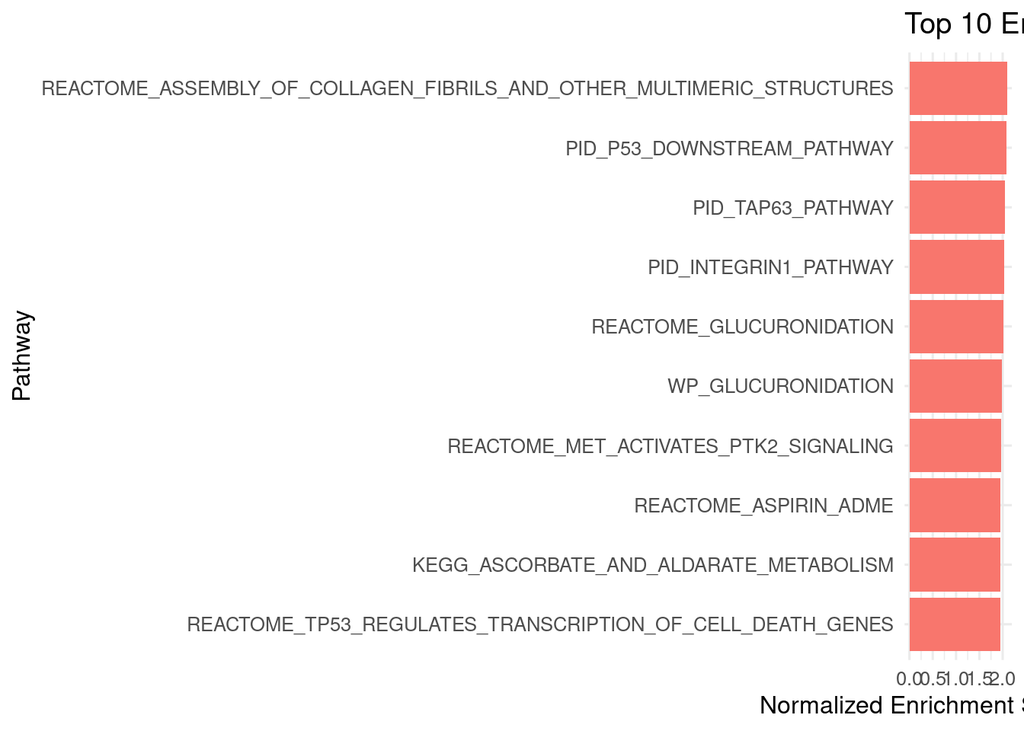

```r
sig_fgsea <- fgseaRes %>%
  filter(padj < 0.05) %>%
  arrange(desc(NES)) %>%
  head(10) %>%
  mutate(pathway = factor(pathway, levels = rev(pathway)))

ggplot(sig_fgsea, aes(x = pathway, y = NES, fill = NES > 0)) +
  geom_col(show.legend = FALSE) +
  coord_flip() +
  labs(title = "Top 10 Enriched Pathways (FGSEA, padj < 0.05)",
       x = "Pathway",
       y = "Normalized Enrichment Score (NES)") +
  theme_minimal(base_size = 12)
```

### FGSEA Analysis Report

Using FGSEA with the C2 canonical pathways collection, several biologically relevant pathways were significantly enriched (padj < 0.01). The most significant terms included REACTOME_NEURONAL_SYSTEM and WP_ADHD_AND_AUTISM_ASD_PATHWAYS, both negatively enriched, suggesting a downregulation of genes involved in neuronal signaling, synaptic communication, and neurodevelopmental functions in the experimental condition. In contrast, positively enriched pathways such as PID_P53_DOWNSTREAM_PATHWAY and WP_IL18_SIGNALING point to an activation of stress-response, apoptosis, and inflammatory signaling networks. Together, these results suggest that the experimental treatment may suppress neuronal and developmental gene programs while upregulating cellular stress and immune-related responses, consistent with a shift from normal signaling activity toward stress or damage-associated processes.

```r
install.packages('sessioninfo')
```